# Tracheid and Xylem Laser Microdissection Project, combined biological QA

Nicolas Delhomme

2016-03-17

# 1 Setup

Set the working dir

```r
setwd("/mnt/picea/projects/spruce/akaerkoenen/laser-capture-microdissection-olga/htseq")
```

Load libraries

```r
suppressPackageStartupMessages(library(DESeq2))
suppressPackageStartupMessages(library(gplots))
suppressPackageStartupMessages(library(pander))
suppressPackageStartupMessages(library(parallel))
suppressPackageStartupMessages(library(RColorBrewer))
suppressPackageStartupMessages(library(scatterplot3d))
suppressPackageStartupMessages(library(vsn))
```

Source some helper functions

```r
source("~/Git/UPSCb/src/R/plot.multidensity.R")
```

Create a palette

```r
pal <- c(1,2,brewer.pal(8,"Dark2"))
```

Register the default plot margin

```r
mar <- par("mar")
```

Read the sample information

```r
samples <- read.csv("~/Git/UPSCb/projects/spruce-LMD/doc/Lignifying-xylem-of-Norway-spruce_Samples.csv")
```

Read the HTSeq files in a matrix

```r
res <- mclapply(dir(".",pattern="*.txt",full.names=TRUE),function(fil){
  read.delim(fil,header=FALSE,stringsAsFactors=FALSE)
},mc.cores=max(mcaffinity()))
```

and rename the samples

```r
names(res) <- sapply(dir(".",pattern="*.txt"),function(n,s){
  gsub(" ","-",s[grep(sub("_sortmerna_trimmomatic_STAR.txt","",n),s$FileName)[1],"SampleName"])
},samples)
```

# 2 Raw Data QC analysis

```r
addInfo <- c("__no_feature","__ambiguous","__too_low_aQual","__not_aligned","__alignment_not_unique")
sel <- match(addInfo,res[[1]][,1])
count.table <- do.call(cbind,lapply(res,"[",2))[-sel,]
colnames(count.table) <- names(res)
rownames(count.table) <- res[[1]][,1][-sel]
dir.create(file.path("..","analysis","HTSeq"),recursive = TRUE, showWarnings = FALSE)
write.csv(count.table,"../analysis/HTSeq/raw-unormalised-data.csv")
```

## 2.1 HTSeq stats

Extract the HTSeq stat lines

```r
count.stats <- do.call(cbind,lapply(res,"[",2))[sel,]
colnames(count.stats) <- names(res)
rownames(count.stats) <- sub("__","",addInfo)
count.stats <- rbind(count.stats,aligned=colSums(count.table))
count.stats <- count.stats[rowSums(count.stats) > 0,]
```

as percentages

```r
pander(apply(count.stats,2,function(co){round(co*100/sum(co))}))
```

Table continues below

|  | S1-ray-cells | S1-ray-cells | S1-ray-cells |
| --- | --- | --- | --- |
| **no_feature** | 62 | 62 | 62 |
| **ambiguous** | 0 | 0 | 0 |
| **alignment_not_unique** | 25 | 25 | 25 |
| **aligned** | 13 | 13 | 13 |

Table continues below

|  | S1-ray-cells | S1-xylem-tracheids |
| --- | --- | --- |
| **no_feature** | 62 | 17 |
| **ambiguous** | 0 | 1 |
| **alignment_not_unique** | 24 | 12 |
| **aligned** | 13 | 70 |

Table continues below

|  | S1-xylem-tracheids | S1-xylem-tracheids |
| --- | --- | --- |
| **no_feature** | 17 | 17 |
| **ambiguous** | 1 | 1 |
| **alignment_not_unique** | 12 | 12 |
| **aligned** | 71 | 71 |

Table continues below

|  | S1-xylem-tracheids | S1-whole-sections |
| --- | --- | --- |
| **no_feature** | 17 | 24 |
| **ambiguous** | 1 | 1 |
| **alignment_not_unique** | 11 | 13 |
| **aligned** | 71 | 62 |

Table continues below

|  | S1-whole-sections | S1-whole-sections |
| --- | --- | --- |
| **no_feature** | 24 | 24 |
| **ambiguous** | 1 | 1 |
| **alignment_not_unique** | 13 | 13 |
| **aligned** | 63 | 62 |

Table continues below

|  | S1-whole-sections | S3-ray-cells | S3-ray-cells |
| --- | --- | --- | --- |
| **no_feature** | 23 | 38 | 37 |
| **ambiguous** | 1 | 0 | 0 |
| **alignment_not_unique** | 13 | 23 | 23 |
| **aligned** | 63 | 39 | 40 |

Table continues below

|  | S3-ray-cells | S3-ray-cells | S3-xylem-tracheids |
| --- | --- | --- | --- |
| **no_feature** | 37 | 37 | 35 |
| **ambiguous** | 0 | 0 | 0 |
| **alignment_not_unique** | 23 | 23 | 18 |
| **aligned** | 40 | 40 | 46 |

Table continues below

|  | S3-xylem-tracheids | S3-xylem-tracheids |
| --- | --- | --- |
| **no_feature** | 35 | 35 |
| **ambiguous** | 0 | 0 |
| **alignment_not_unique** | 18 | 18 |
| **aligned** | 47 | 46 |

Table continues below

|  | S3-xylem-tracheids | S3-whole-sections |
| --- | --- | --- |
| **no_feature** | 35 | 37 |
| **ambiguous** | 0 | 0 |
| **alignment_not_unique** | 18 | 16 |
| **aligned** | 47 | 47 |

Table continues below

|  | S3-whole-sections | S3-whole-sections |
| --- | --- | --- |
| **no_feature** | 37 | 37 |
| **ambiguous** | 0 | 0 |
| **alignment_not_unique** | 16 | 16 |
| **aligned** | 47 | 47 |

Table continues below

|  | S3-whole-sections | S2-whole-sections |
| --- | --- | --- |
| **no_feature** | 37 | 23 |
| **ambiguous** | 0 | 1 |
| **alignment_not_unique** | 16 | 12 |
| **aligned** | 47 | 65 |

Table continues below

|  | S2-whole-sections | S2-whole-sections |
| --- | --- | --- |
| **no_feature** | 23 | 23 |
| **ambiguous** | 1 | 1 |
| **alignment_not_unique** | 12 | 12 |
| **aligned** | 65 | 65 |

Table continues below

|  | S2-whole-sections | S4-whole-sections |
| --- | --- | --- |
| **no_feature** | 23 | 44 |
| **ambiguous** | 1 | 0 |
| **alignment_not_unique** | 12 | 32 |
| **aligned** | 65 | 23 |

Table continues below

|  | S4-whole-sections | S4-whole-sections |
| --- | --- | --- |
| **no_feature** | 44 | 44 |
| **ambiguous** | 0 | 0 |
| **alignment_not_unique** | 32 | 32 |
| **aligned** | 24 | 24 |

Table continues below

|  | S4-whole-sections | S2-ray-cells | S2-ray-cells |
| --- | --- | --- | --- |
| **no_feature** | 44 | 24 | 23 |
| **ambiguous** | 0 | 0 | 0 |
| **alignment_not_unique** | 32 | 13 | 13 |
| **aligned** | 24 | 63 | 63 |

Table continues below

|  | S2-ray-cells | S2-ray-cells | S2-xylem-tracheids |
| --- | --- | --- | --- |
| **no_feature** | 23 | 23 | 21 |
| **ambiguous** | 0 | 0 | 1 |
| **alignment_not_unique** | 13 | 13 | 10 |
| **aligned** | 63 | 64 | 68 |

Table continues below

|  | S2-xylem-tracheids | S2-xylem-tracheids |
| --- | --- | --- |
| **no_feature** | 21 | 21 |
| **ambiguous** | 1 | 1 |
| **alignment_not_unique** | 10 | 10 |
| **aligned** | 69 | 69 |

|  | S2-xylem-tracheids |
| --- | --- |
| **no_feature** | 21 |
| **ambiguous** | 1 |
| **alignment_not_unique** | 10 |
| **aligned** | 69 |

as a plot

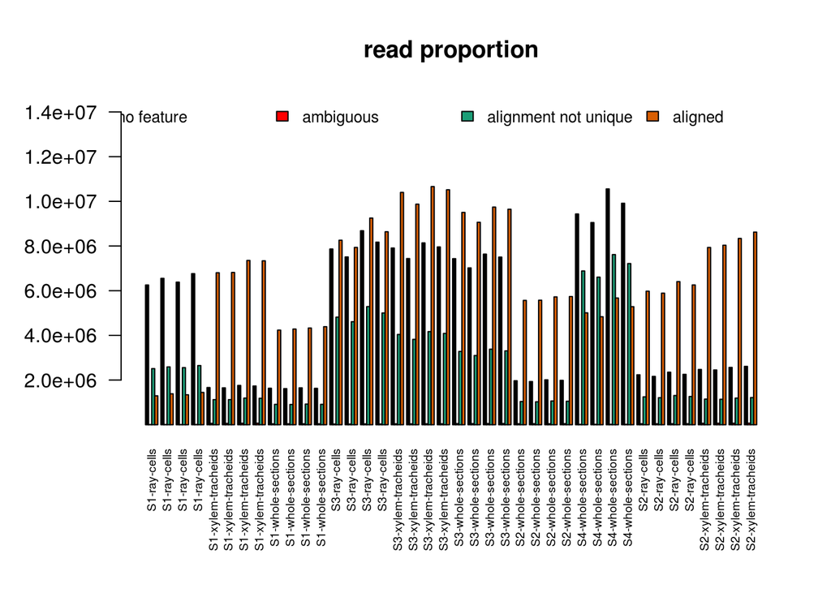

```r
col <- pal[1:nrow(count.stats)]
par(mar=c(7.1,5.1,4.1,2.1))
barplot(as.matrix(count.stats),col=col,beside=TRUE,las=2,main="read proportion",
        ylim=range(count.stats) + c(0,4e+6),cex.names=.6)
legend("top",fill=col,legend=gsub("_"," ",rownames(count.stats)),bty="n",cex=0.8,horiz=TRUE)
```

```r
par(mar=mar)
```

## 2.2 Raw expression summary

### 2.2.1 Percentage of aligned reads

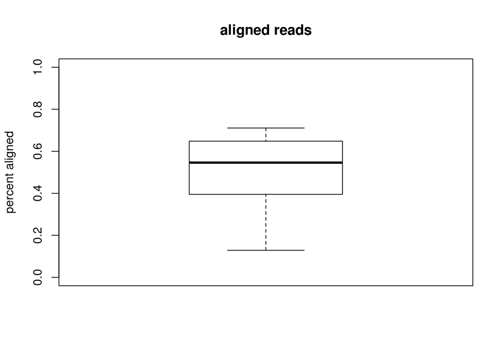

```r
boxplot(unlist(count.stats["aligned",]/colSums(count.stats)),
        main="aligned reads",ylab="percent aligned",ylim=c(0,1))
```

### 2.2.2 Amount of un-expressed

```r
sel <- rowSums(count.table) == 0
sprintf("%s%% percent (%s) of %s genes are not expressed",
        round(sum(sel) * 100/ nrow(count.table),digits=1),
        sum(sel),
        nrow(count.table))
```

```
## [1] "23.9% percent (16913) of 70736 genes are not expressed"
```

### 2.2.3 Overall average expression

Display the per-gene mean expression

i.e. the mean raw count of every gene across samples is calculated and displayed on a log10 scale.

The curve looks usual but is slightly more enriched for lower counts. It has a peak around 1.5 on a log10 scale, so an average gene coverage of 30X per technical replicates. If the replicates can be merged - which seem to be the case - that would mean an average 120X average coverage which is ideal for a Differential Expression (DE) analysis.

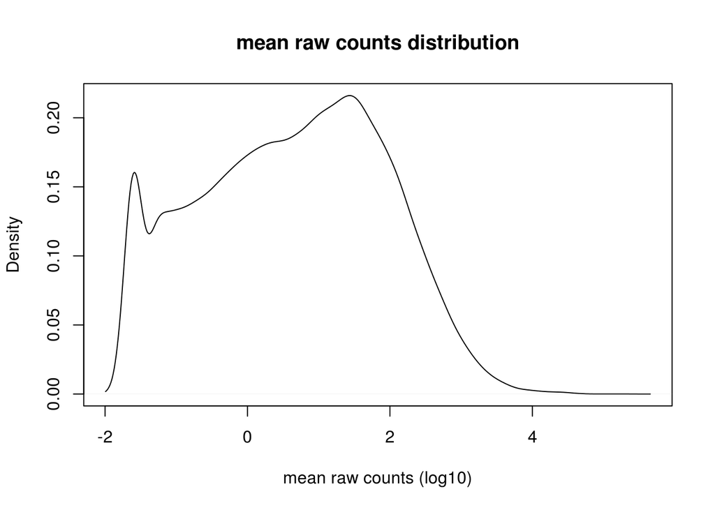

```r
plot(density(log10(rowMeans(count.table))),col=pal[1],
     main="mean raw counts distribution",
     xlab="mean raw counts (log10)")
```

### 2.2.4 Per sample expression

The same as above is done for the individual samples colored by sample type

The observed distribution is strickingly identical between technical replicates. The samples however have different coverage - i.e. different effective sequencing depth.

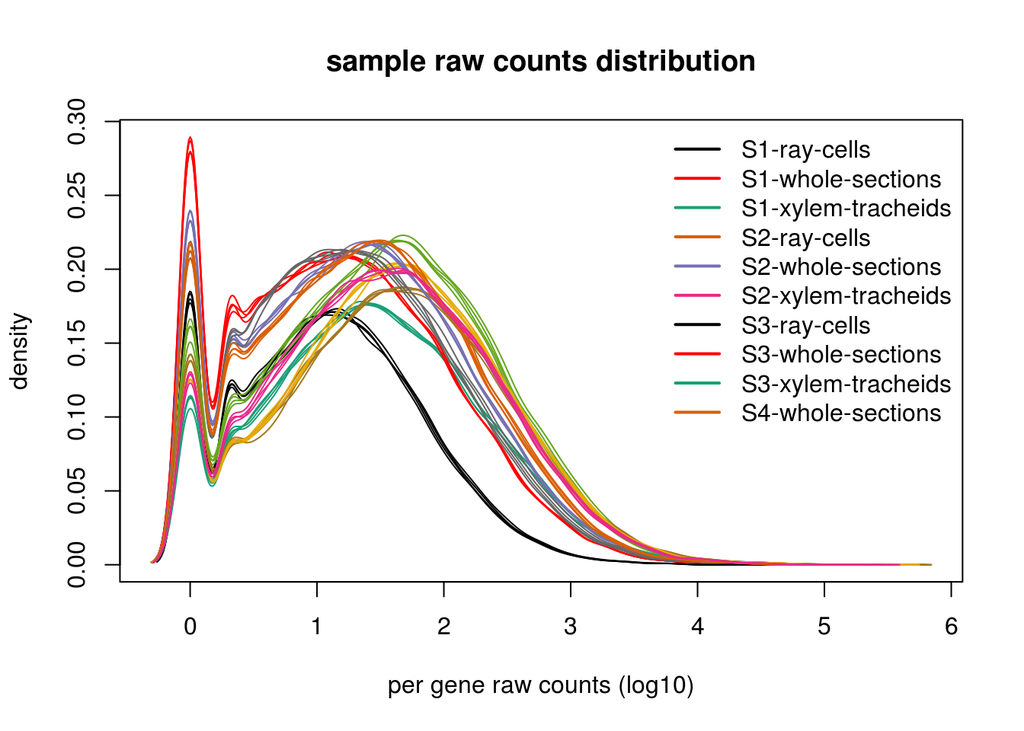

```r
plot.multidensity(log10(count.table),
                  col=pal[as.integer(factor(colnames(count.table)))],
                  legend.x="topright",
                  legend=levels(factor(colnames(count.table))),
                  legend.col=pal[1:6],
                  legend.lwd=2,
                  main="sample raw counts distribution",
                  xlab="per gene raw counts (log10)")
```

# 3 Data normalisation

For visualization, the data is submitted to a variance stabilization transformation using DESeq2. The dispersion is estimated independently of the sample type and sample experiment

```r
conditions <- colnames(count.table)
dds <- DESeqDataSetFromMatrix(
  countData = count.table,
  colData = data.frame(condition=conditions),
  design = ~ condition)
```

## 3.1 Library size Factor (a.k.a. scaling factor)

Here, we check the size factors (i.e. the sequencing library size effect). There is some large variation, making a VST transformation borderline. A rlog transformation should be prefered, but for QC purposes, a VST is sufficient.

```r
dds <- estimateSizeFactors(dds)
sizes <- sizeFactors(dds)
names(sizes) <- colnames(count.table)
```

The size factors calculated by DESeq2 display the same information as the raw expression density plots above; which is expected.

```r
pander(sizes)
```

Table continues below

| S1-ray-cells | S1-ray-cells | S1-ray-cells | S1-ray-cells | S1-xylem-tracheids |
| --- | --- | --- | --- | --- |
| 0.2623 | 0.2777 | 0.2709 | 0.2907 | 0.9071 |

Table continues below

| S1-xylem-tracheids | S1-xylem-tracheids | S1-xylem-tracheids |
| --- | --- | --- |
| 0.9062 | 0.9749 | 0.9681 |

Table continues below

| S1-whole-sections | S1-whole-sections | S1-whole-sections | S1-whole-sections |
| --- | --- | --- | --- |
| 0.7106 | 0.713 | 0.7286 | 0.7327 |

Table continues below

| S3-ray-cells | S3-ray-cells | S3-ray-cells | S3-ray-cells | S3-xylem-tracheids |
| --- | --- | --- | --- | --- |
| 1.66 | 1.585 | 1.853 | 1.736 | 1.618 |

Table continues below

| S3-xylem-tracheids | S3-xylem-tracheids | S3-xylem-tracheids |
| --- | --- | --- |
| 1.532 | 1.653 | 1.636 |

Table continues below

| S3-whole-sections | S3-whole-sections | S3-whole-sections | S3-whole-sections |
| --- | --- | --- | --- |
| 1.665 | 1.587 | 1.717 | 1.696 |

Table continues below

| S2-whole-sections | S2-whole-sections | S2-whole-sections | S2-whole-sections |
| --- | --- | --- | --- |
| 0.9863 | 0.9862 | 1.016 | 1.007 |

Table continues below

| S4-whole-sections | S4-whole-sections | S4-whole-sections | S4-whole-sections |
| --- | --- | --- | --- |
| 0.8578 | 0.8291 | 0.9738 | 0.9019 |

Table continues below

| S2-ray-cells | S2-ray-cells | S2-ray-cells | S2-ray-cells | S2-xylem-tracheids |
| --- | --- | --- | --- | --- |
| 1.155 | 1.138 | 1.236 | 1.199 | 1.446 |

| S2-xylem-tracheids | S2-xylem-tracheids | S2-xylem-tracheids |
| --- | --- | --- |
| 1.455 | 1.516 | 1.557 |

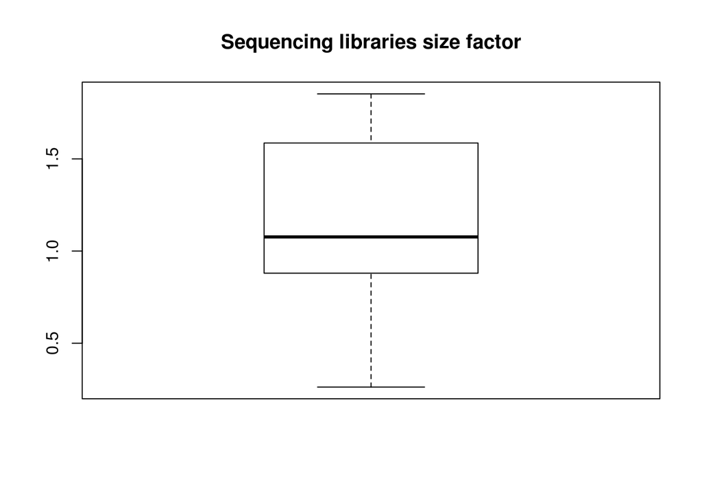

```r
boxplot(sizes, main="Sequencing libraries size factor")
```

## 3.2 Variance Stabilising Transformation (VST)

The data is transformed to be homoscedastic, and shifted so that non-expressed genes have a value of 0. The resulting table, containing all replicates, is saved.

```r
colData(dds)$condition <- factor(colData(dds)$condition,
                                 levels=unique(conditions))
vsd <- varianceStabilizingTransformation(dds, blind=TRUE)
vst <- assay(vsd)
colnames(vst) <- colnames(count.table)
vst <- vst - min(vst)
write.csv(vst,"../analysis/HTSeq/library-size-normalized_variance-stabilized_data.csv")
```

## 3.3 VST validation

We visualize the corrected mean - sd relationship to assess whether homoscedasticity can be assumed. The red line should ideally be linear, and the standard deviation (sd) should be contained below 0.5.

As expected the normalisation is not optimal, the homoscedasticity is reached only for highy expressed genes.

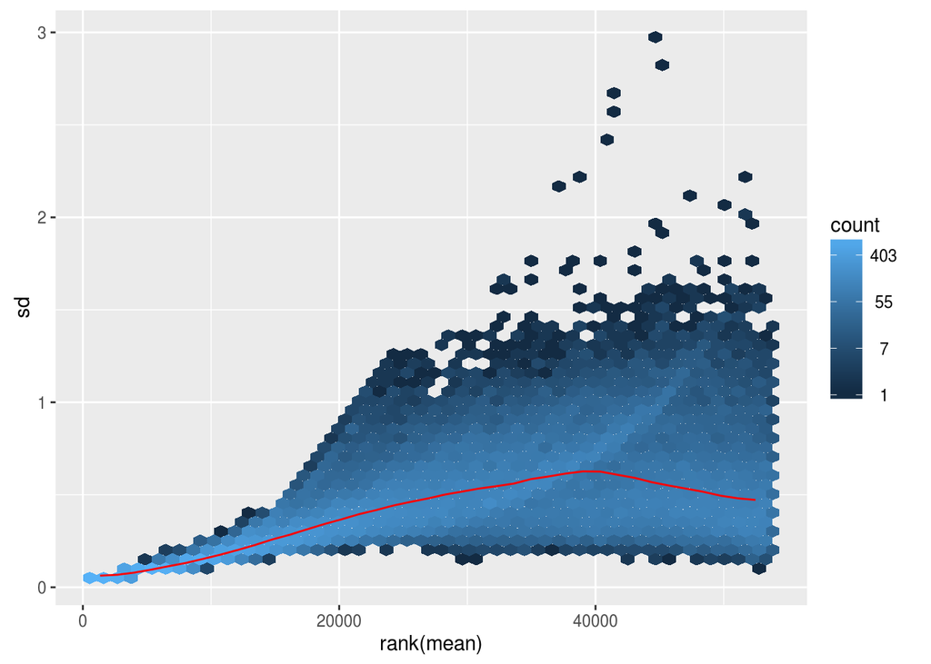

```r
meanSdPlot(vst[rowSums(count.table)>0,])
```

# 4 QC on the normalised data

## 4.1 Principal Component Analysis (PCA)

We perform a PCA of the data to do a quick quality assessment; i.e. replicate should cluster together and the first 2-3 dimensions should be explainable by biological means.

```r
pc <- prcomp(t(vst))
percent <- round(summary(pc)$importance[2,]*100)
```

### 4.1.1 PCA 3 first dimensions

Here we do plot all technical rrplicates, but as can be seen, they are undistinguishable from one another. Sample S1 ray cells is an obvious outlier.

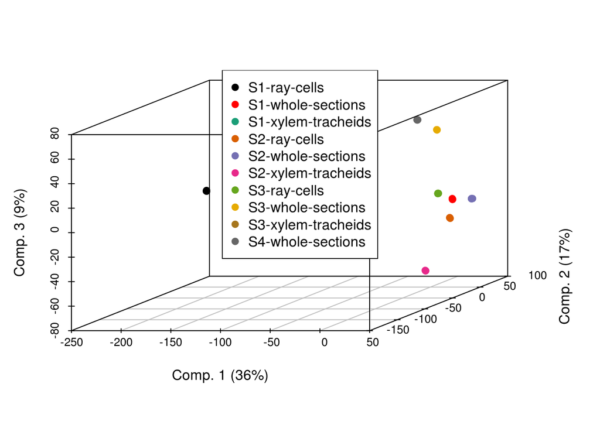

```r
mar=c(5.1,4.1,4.1,2.1)
scatterplot3d(pc$x[,1],
              pc$x[,2],
              pc$x[,3],
              xlab=paste("Comp. 1 (",percent[1],"%)",sep=""),
              ylab=paste("Comp. 2 (",percent[2],"%)",sep=""),
              zlab=paste("Comp. 3 (",percent[3],"%)",sep=""),
              color=pal[as.integer(factor(colnames(count.table)))],
              pch=19)
legend("top",pch=19,
       col=pal,
       legend=levels(factor(colnames(count.table))))
```

```r
par(mar=mar)
```

### 4.1.2 The first two dimensions

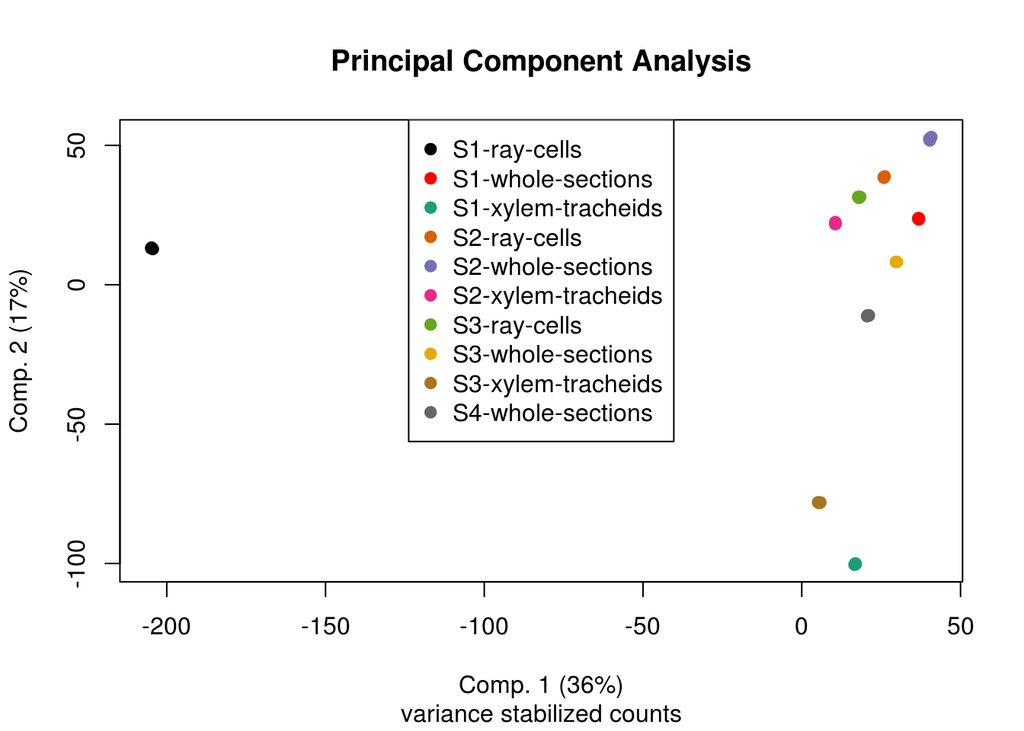

```r
plot(pc$x[,1],
     pc$x[,2],
     xlab=paste("Comp. 1 (",percent[1],"%)",sep=""),
     ylab=paste("Comp. 2 (",percent[2],"%)",sep=""),
     col=pal[as.integer(factor(colnames(count.table)))],
     pch=19,
     main="Principal Component Analysis",sub="variance stabilized counts")

legend("top",pch=19,
       col=pal,
       legend=levels(factor(colnames(count.table))))
```

### 4.1.3 The 2nd and 3rd dims

The 2nd dimension (accounting 17% of the overall variance) nor the third dimension seem to have a biological explanation.

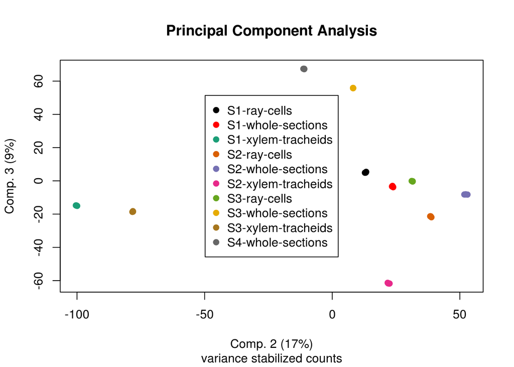

```r
plot(pc$x[,2],
     pc$x[,3],
     xlab=paste("Comp. 2 (",percent[2],"%)",sep=""),
     ylab=paste("Comp. 3 (",percent[3],"%)",sep=""),
     col=pal[as.integer(factor(colnames(count.table)))],
     pch=19,
     main="Principal Component Analysis",sub="variance stabilized counts")

legend("center",pch=19,
       col=pal,
       legend=levels(factor(colnames(count.table))))
```

## 4.2 Heatmap

The 1000 most variable genes are selected and plotted as a heatmap. The results recapitulate what we have observed in the PCA.

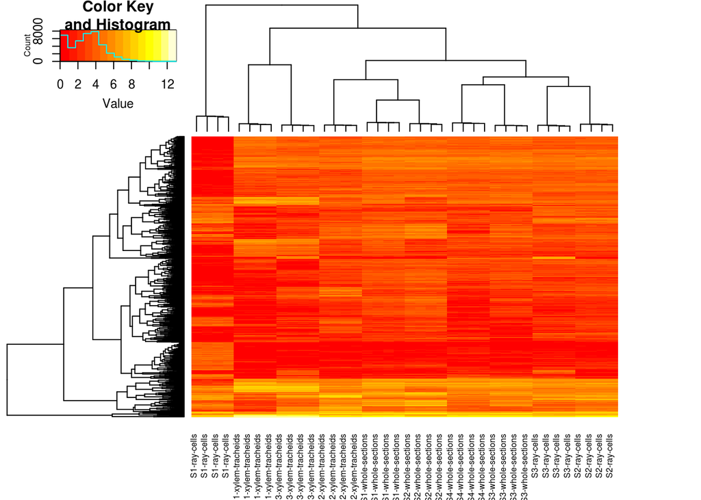

```r
dimnames(vst) <- dimnames(count.table)
sel <- order(apply(vst,1,sd),decreasing=TRUE)[1:1000]
heatmap.2(vst[sel,],labRow = NA,trace = "none",cexCol = 0.6 )
```

Looking at the PCA of the same genes does not reveal a clearer pattern.

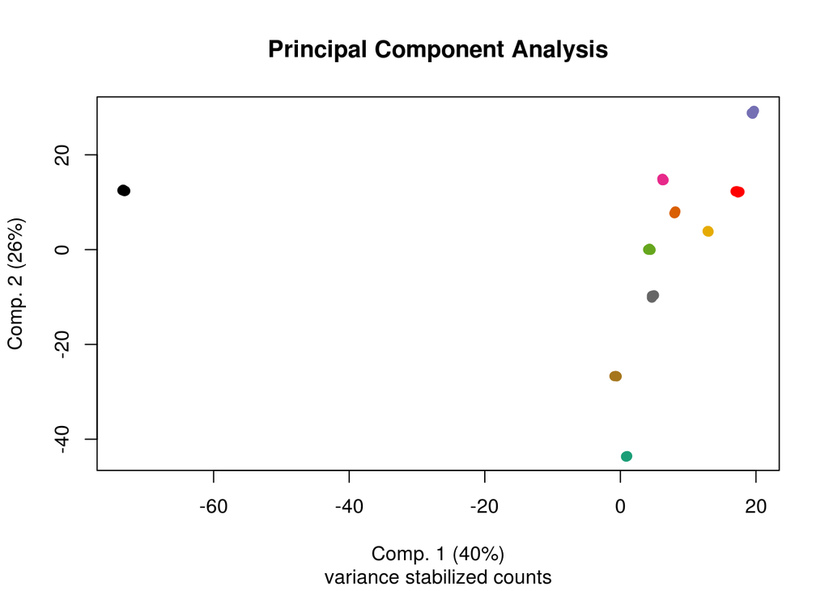

```r
pc <- prcomp(t(vst[sel,]))
percent <- round(summary(pc)$importance[2,]*100)

plot(pc$x[,1],
     pc$x[,2],
     xlab=paste("Comp. 1 (",percent[1],"%)",sep=""),
     ylab=paste("Comp. 2 (",percent[2],"%)",sep=""),
     col=pal[as.integer(factor(colnames(count.table)))],
     pch=19,
     main="Principal Component Analysis",sub="variance stabilized counts")
```

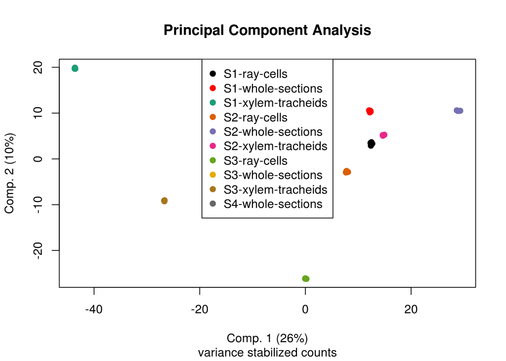

```r
plot(pc$x[,2],
     pc$x[,3],
     xlab=paste("Comp. 1 (",percent[2],"%)",sep=""),
     ylab=paste("Comp. 2 (",percent[3],"%)",sep=""),
     col=pal[as.integer(factor(colnames(count.table)))],
     pch=19,
     main="Principal Component Analysis",sub="variance stabilized counts")

legend("top",pch=19,
       col=pal,
       legend=levels(factor(colnames(count.table))))
```

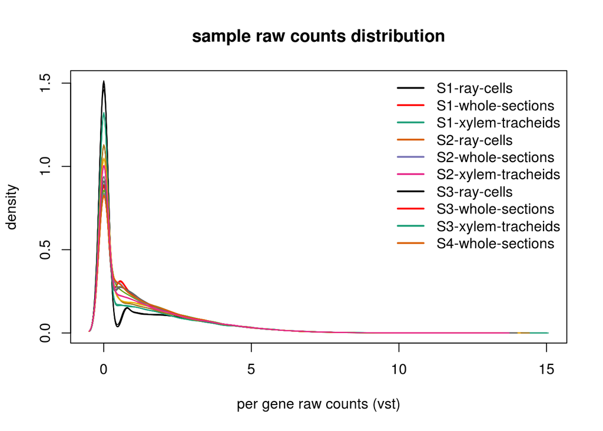

```r
plot.multidensity(as.data.frame(vst[rowSums(vst)>0,]),
                  col=pal[as.integer(factor(colnames(count.table)))],
                  legend.x="topright",
                  legend=levels(factor(colnames(count.table))),
                  legend.col=pal[1:6],
                  legend.lwd=2,
                  main="sample raw counts distribution",
                  xlab="per gene raw counts (vst)")
```

# 5 Conclusion

From the QA, it is evident that the technical replicates are identical and hence that we can merge them. However there are technicalities which prevent an immediate use of the data for differential expression. Presumably a lot of the technical variability has been introduced by the amplification protocol used (very low amount of starting material was available).

```r
m.count.table <- sapply(unique(colnames(count.table)),function(n,m){
  rowSums(m[,colnames(m)==n])
},count.table)
write.csv(m.count.table,"../analysis/HTSeq/raw-unormalised_merged-technical-replicates_data.csv")
```

# 6 Follow up

I will next try different approaches to identify an adequate cutoff for reducing the noise, including looking at estimates of dispersion, relative mean difference, expression specificity (by sample and tissues).